# Predict Bike Sharing Demand with AutoGluon Template

## Step 3: Train a model using AutoGluon’s Tabular Prediction

Requirements:

- We are predicting `count`, so it is the label we are setting.
- Ignore `casual` and `registered` columns as they are also not present in the test dataset.
- Use the `root_mean_squared_error` as the metric to use for evaluation.
- Set a time limit of 10 minutes (600 seconds).
- Use the preset `best_quality` to focus on creating the best model.

```python
predictor = TabularPredictor(label="count", eval_metric="root_mean_squared_error").fit(train_data=train,
                                                time_limit=600,
                                                presets="best_quality")
```

[output not shown]

[output cut: 67 more lines]

```
	Fitting 8 child models (S1F1 - S1F8) | Fitting with ParallelLocalFoldFittingStrategy
	-55.5225	 = Validation score   (-root_mean_squared_error)
	61.5s	 = Training   runtime
	0.06s	 = Validation runtime
Fitting model: ExtraTreesMSE_BAG_L2 ... Training model for up to 0.66s of the 0.64s of remaining time.
	-53.8249	 = Validation score   (-root_mean_squared_error)
	8.36s	 = Training   runtime
	0.58s	 = Validation runtime
Completed 1/20 k-fold bagging repeats ...
Fitting model: WeightedEnsemble_L3 ... Training model for up to 360.0s of the -11.09s of remaining time.
	-52.8054	 = Validation score   (-root_mean_squared_error)
	0.59s	 = Training   runtime
	0.0s	 = Validation runtime
AutoGluon training complete, total runtime = 611.91s ... Best model: "WeightedEnsemble_L3"
TabularPredictor saved. To load, use: predictor = TabularPredictor.load("AutogluonModels/ag-20221217_172639/")
```

### Review AutoGluon's training run with ranking of models that did the best.

```python
predictor.fit_summary()
```

```
*** Summary of fit() ***
Estimated performance of each model:
                     model   score_val  pred_time_val    fit_time  pred_time_val_marginal  fit_time_marginal  stack_level  can_infer  fit_order
0      WeightedEnsemble_L3  -52.805376      11.624005  511.729374                0.001001           0.594293            3       True         15
1   RandomForestMSE_BAG_L2  -53.397954      10.762270  416.150596                0.591436          26.579105            2       True         12
2     ExtraTreesMSE_BAG_L2  -53.824932      10.752524  397.933818                0.581690           8.362328            2       True         14
3          LightGBM_BAG_L2  -55.087450      10.388393  414.696433                0.217559          25.124942            2       True         11
4          CatBoost_BAG_L2  -55.522524      10.232319  451.068706                0.061485          61.497215            2       True         13
5        LightGBMXT_BAG_L2  -60.399579      14.136581  443.448832                3.965747          53.877342            2       True         10
6    KNeighborsDist_BAG_L1  -84.125061       0.103925    0.034240                0.103925           0.034240            1       True          2
7      WeightedEnsemble_L2  -84.125061       0.104707    0.528742                0.000782           0.494502            2       True          9
8    KNeighborsUnif_BAG_L1 -101.546199       0.102995    0.031045                0.102995           0.031045            1       True          1
9   RandomForestMSE_BAG_L1 -116.544294       0.528359   10.569555                0.528359          10.569555            1       True          5
10    ExtraTreesMSE_BAG_L1 -124.588053       0.531457    4.861875                0.531457           4.861875            1       True          7
11         CatBoost_BAG_L1 -130.503441       0.099801  200.743545                0.099801         200.743545            1       True          6
12         LightGBM_BAG_L1 -131.054162       1.446240   29.977131                1.446240          29.977131            1       True          4
13       LightGBMXT_BAG_L1 -131.460909       6.967209   66.274849                6.967209          66.274849            1       True          3
14  NeuralNetFastAI_BAG_L1 -137.475175       0.390849   77.079252                0.390849          77.079252            1       True          8
Number of models trained: 15
Types of models trained:
{'StackerEnsembleModel_XT', 'WeightedEnsembleModel', 'StackerEnsembleModel_CatBoost', 'StackerEnsembleModel_NNFastAiTabular', 'StackerEnsembleModel_LGB', 'StackerEnsembleModel_KNN', 'StackerEnsembleModel_RF'}
Bagging used: True  (with 8 folds)
Multi-layer stack-ensembling used: True  (with 3 levels)
Feature Metadata (Processed):
(raw dtype, special dtypes):
('float', [])                : 3 | ['temp', 'atemp', 'windspeed']
('int', [])                  : 3 | ['season', 'weather', 'humidity']
('int', ['bool'])            : 2 | ['holiday', 'workingday']
('int', ['datetime_as_int']) : 5 | ['datetime', 'datetime.year', 'datetime.month', 'datetime.day', 'datetime.dayofweek']
Plot summary of models saved to file: AutogluonModels/ag-20221217_172639/SummaryOfModels.html
*** End of fit() summary ***
```

[output not shown]

[output cut: 139 more lines]

```
 0          15
 1          12
 2          14
 3          11
 4          13
 5          10
 6           2
 7           9
 8           1
 9           5
 10          7
 11          6
 12          4
 13          3
 14          8  }
```

### Create predictions from test dataset

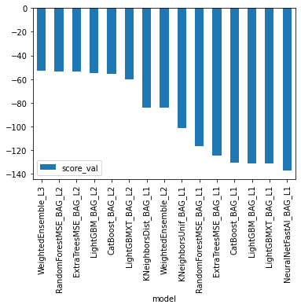

```python
predictor.leaderboard(silent=True).plot(kind="bar", x="model", y="score_val")
```

```python
predictions = predictor.predict(test)
predictions.head()
```

```
0    12.823812
1    50.143299
2    28.644337
3     8.145401
4     3.416314
Name: count, dtype: float32
```

#### NOTE: Kaggle will reject the submission if we don't set everything to be > 0.

```python
# Describe the `predictions` series to see if there are any negative values
predictions.describe()
```

```
count    10886.000000
mean       191.463654
std        212.074432
min         -1.043287
25%         16.514400
50%        115.062519
75%        288.989090
max        833.626099
Name: count, dtype: float64
```

```python
# How many negative values do we have?
len(predictions.loc[(predictions < 0)])
```

```
1
```

```python
# Set them to zero
predictions[predictions < 0 ] = 0
```

```python
predictions.describe()
```

```
count    10886.000000
mean       191.463745
std        212.074341
min          0.000000
25%         16.514400
50%        115.062519
75%        288.989090
max        833.626099
Name: count, dtype: float64
```

### Set predictions to submission dataframe, save, and submit

```python
submission["count"] = predictions
submission.to_csv("submission.csv", index=False)
```

```python
!kaggle competitions submit -c bike-sharing-demand -f submission.csv -m "second raw submission"
```

```
Successfully submitted to Bike Sharing Demand
```

#### View submission via the command line or in the web browser under the competition's page - `My Submissions`

```python
!kaggle competitions submissions -c bike-sharing-demand | tail -n +1 | head -n 6
```

```
fileName                     date                 description            status    publicScore  privateScore
---------------------------  -------------------  ---------------------  --------  -----------  ------------
submission.csv               2022-12-17 19:13:51  second raw submission  complete  2.13533      2.13533
submission.csv               2022-12-17 19:10:12  second raw submission  complete  1.79285      1.79285
submission.csv               2022-12-16 23:02:46  second raw submission  complete  1.79285      1.79285
submission_new_features.csv  2022-12-16 22:44:20  new features           complete  1.78981      1.78981
```

#### Initial score of `2.13533`

## Step 4: Exploratory Data Analysis and Creating an additional feature

- Any additional feature will do, but a great suggestion would be to separate out the datetime into hour, day, or month parts.

[output not shown]

[figure not shown]

```python
# Create a histogram of all features to show the distribution of each one relative to the data. This is part of the exploratory data analysis
#train.hist()
train.hist(figsize=(14,14))
```

```python
train.head()
```

|  | datetime | season | holiday | workingday | weather | temp | atemp | humidity | windspeed | count |
| --- | --- | --- | --- | --- | --- | --- | --- | --- | --- | --- |
| 0 | 2011-01-01 00:00:00 | 1 | 0 | 0 | 1 | 9.84 | 14.395 | 81 | 0.0 | 16 |
| 1 | 2011-01-01 01:00:00 | 1 | 0 | 0 | 1 | 9.02 | 13.635 | 80 | 0.0 | 40 |
| 2 | 2011-01-01 02:00:00 | 1 | 0 | 0 | 1 | 9.02 | 13.635 | 80 | 0.0 | 32 |
| 3 | 2011-01-01 03:00:00 | 1 | 0 | 0 | 1 | 9.84 | 14.395 | 75 | 0.0 | 13 |
| 4 | 2011-01-01 04:00:00 | 1 | 0 | 0 | 1 | 9.84 | 14.395 | 75 | 0.0 | 1 |

```python
# create a new feature


#df['weekday'] = df['Timestamp'].dt.dayofweek
train['weekday'] = train['datetime'].dt.dayofweek
test['weekday'] = test['datetime'].dt.dayofweek

# convert new feature to a category dtype

train["weekday"] = train.weekday.astype('category')
test["weekday"] = test.weekday.astype('category')
```